# Shrinkage Methods

Ryan Yee

Ridge Regression and the Lasso

**Dataset** The dataset for analysis is the Major League Baseball Data from the 1986 and 1987 seasons, which consists of 322 observations of major league players on 20 variables including the number of hits, number of errors, annual salary etc. Before proceeding, we first import required packages and ensure that the missing values have been removed.

```r
library(ISLR)
library(glmnet)
library(dplyr)
library(tidyr)
```

Before proceeding, let’s first ensure that the missing values have been removed from the data.

```r
Hitters = na.omit(Hitters)
```

We will perform ridge regression and the lasso later in order to predict Salary on the Hitters data. Let’s set up our data first.

```r
x = model.matrix(Salary~., Hitters)[,-1] # trim off the first column
                                         # leaving only the predictors
y = Hitters$Salary
```

The `model.matrix()` function is particularly useful for creating $x$; not only does it produce a matrix corresponding to the 19 predictors but it also automatically transforms any qualitative variables into dummy variables. The latter property is important because `glmnet()` can only take numerical, quantitative inputs.

# Ridge Regression and Lasso Regression

Ridge and lasso can be accomplished using the glmnet package. The main function in this package is glmnet(), which can be used to fit ridge regression models, lasso models, and more. This function has slightly different syntax from other model-fitting functions. In particular, we must pass in an x (as predictors matrix) as well as a y (response vector), and we do not use the y ∼ x syntax.

```r
grid = 10^seq(10, -2, length = 100)
ridge_mod = glmnet(x, y, alpha = 0, lambda = grid)
```

By default the `glmnet()` function performs ridge regression for an automatically selected range of $\lambda$ values. However, here we have chosen to implement the function over a grid of values ranging from $\lambda = 10^{10}$ to $\lambda = 10^{-2}$, essentially covering the full range of scenarios from the null model containing only the intercept, to the least squares fit.

As we will see, we can also compute model fits for a particular value of $\lambda$ that is not one of the original grid values. Note that by default, the `glmnet()` function standardizes the variables so that they are on the same scale. To turn off this default setting, use the argument `standardize = FALSE`.

Associated with each value of $\lambda$ is a vector of ridge regression coefficients, stored in a matrix that can be accessed by `coef()`. In this case, it is a $20 \times 100$ matrix, with 20 rows (one for each predictor, plus an intercept) and 100 columns (one for each value of $\lambda$).

We expect the coefficient estimates to be much smaller, in terms of $l_2$ norm, when a large value of $\lambda$ is used, as compared to when a small value of $\lambda$ is used. These are the coefficients when $\lambda = 11498$, along with their $l_2$ norm:

```r
ridge_mod$lambda[50] #Display 50th lambda value
```

```
## [1] 11497.57
```

```r
coef(ridge_mod)[,50] # Display coefficients associated with 50th lambda value
```

```
##   (Intercept)         AtBat          Hits         HmRun          Runs
## 407.356050200   0.036957182   0.138180344   0.524629976   0.230701523
##           RBI         Walks         Years        CAtBat         CHits
##   0.239841459   0.289618741   1.107702929   0.003131815   0.011653637
##        CHmRun         CRuns          CRBI        CWalks       LeagueN
##   0.087545670   0.023379882   0.024138320   0.025015421   0.085028114
##     DivisionW       PutOuts       Assists        Errors    NewLeagueN
##  -6.215440973   0.016482577   0.002612988  -0.020502690   0.301433531
```

```r
sqrt(sum(coef(ridge_mod)[-1,50]^2)) # Calculate l2 norm
```

```
## [1] 6.360612
```

In contrast, here are the coefficients when $\lambda = 705$, along with their $l_2$ norm. Note the much larger $l_2$ norm of the coefficients associated with this smaller value of $\lambda$.

```r
ridge_mod$lambda[60] #Display 60th lambda value
```

```
## [1] 705.4802
```

```r
coef(ridge_mod)[,60] # Display coefficients associated with 60th lambda value
```

```
##  (Intercept)        AtBat         Hits        HmRun         Runs          RBI
##  54.32519950   0.11211115   0.65622409   1.17980910   0.93769713   0.84718546
##        Walks        Years       CAtBat        CHits       CHmRun        CRuns
##   1.31987948   2.59640425   0.01083413   0.04674557   0.33777318   0.09355528
##         CRBI       CWalks      LeagueN    DivisionW      PutOuts      Assists
##   0.09780402   0.07189612  13.68370191 -54.65877750   0.11852289   0.01606037
##       Errors   NewLeagueN
##  -0.70358655   8.61181213
```

```r
sum(coef(ridge_mod)[-1,60]^2) # Calculate l2 norm squared
```

```
## [1] 3261.554
```

```r
pred <- pred <- predict(object = ridge_mod, newx = x)
```

Use cv.glmnet (Cross-validation) to Choose the Best Tuning Parameter

Instead of arbitrarily choosing a value of λ, it would be better to use cross-validation to choose the tuning parameter λ. We can do this using the built-in cross-validation function, cv.glmnet(). By default, the function performs ten-fold cross-validation, though this can be changed using the argument “folds”.

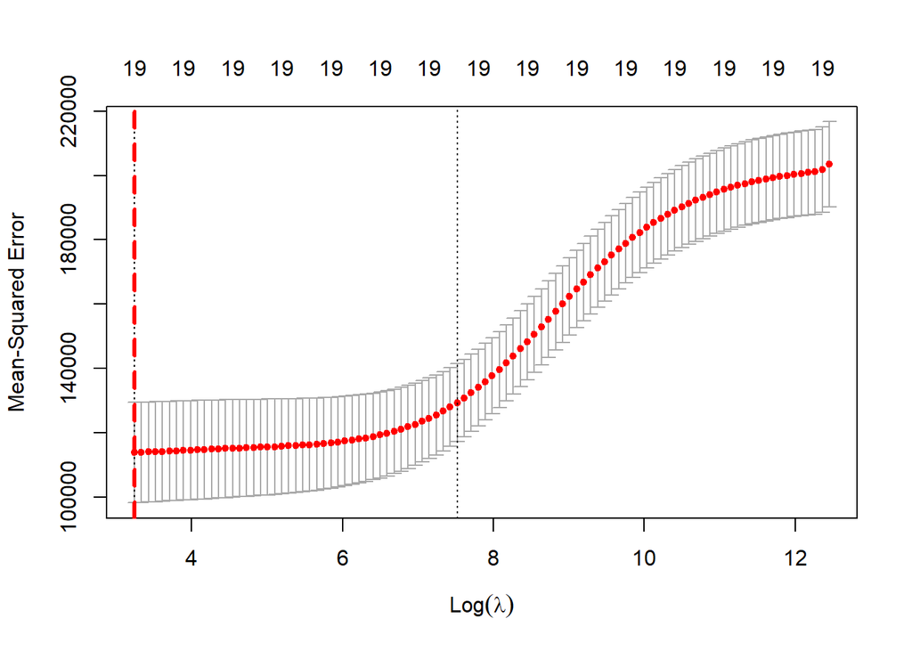

```r
set.seed(1) #we set a random seed first so our results will be reproducible.
cv.out.ridge=cv.glmnet(x, y, alpha = 0)
plot(cv.out.ridge)
abline(v = log(cv.out.ridge$lambda.min), col="red", lwd=3, lty=2)
```

```r
bestlam = cv.out.ridge$lambda.min
bestlam
```

```
## [1] 25.52821
```

```r
out = glmnet(x,y,alpha=0)
predict(out,type="coefficients",s=bestlam)[1:20,]
```

```
##   (Intercept)         AtBat          Hits         HmRun          Runs
##  8.112693e+01 -6.815959e-01  2.772312e+00 -1.365680e+00  1.014826e+00
##           RBI         Walks         Years        CAtBat         CHits
##  7.130224e-01  3.378558e+00 -9.066800e+00 -1.199478e-03  1.361029e-01
##        CHmRun         CRuns          CRBI        CWalks       LeagueN
##  6.979958e-01  2.958896e-01  2.570711e-01 -2.789666e-01  5.321272e+01
##     DivisionW       PutOuts       Assists        Errors    NewLeagueN
## -1.228345e+02  2.638876e-01  1.698796e-01 -3.685645e+00 -1.810510e+01
```

This is the best model given from the ridge regression. Notice that none of the coefficients are zero. Ridge regression does not perform variable selection!

The lasso has the nice feature that it will set many of the coefficient estimates as exactly 0. This is useful when some of the variables used in a multiple regression model are in fact not associated with the response. By removing these variables (by setting the corresponding coefficient estimates to zero), we obtain a model that is more interpretable. This is sometimes referred to as variable selection.

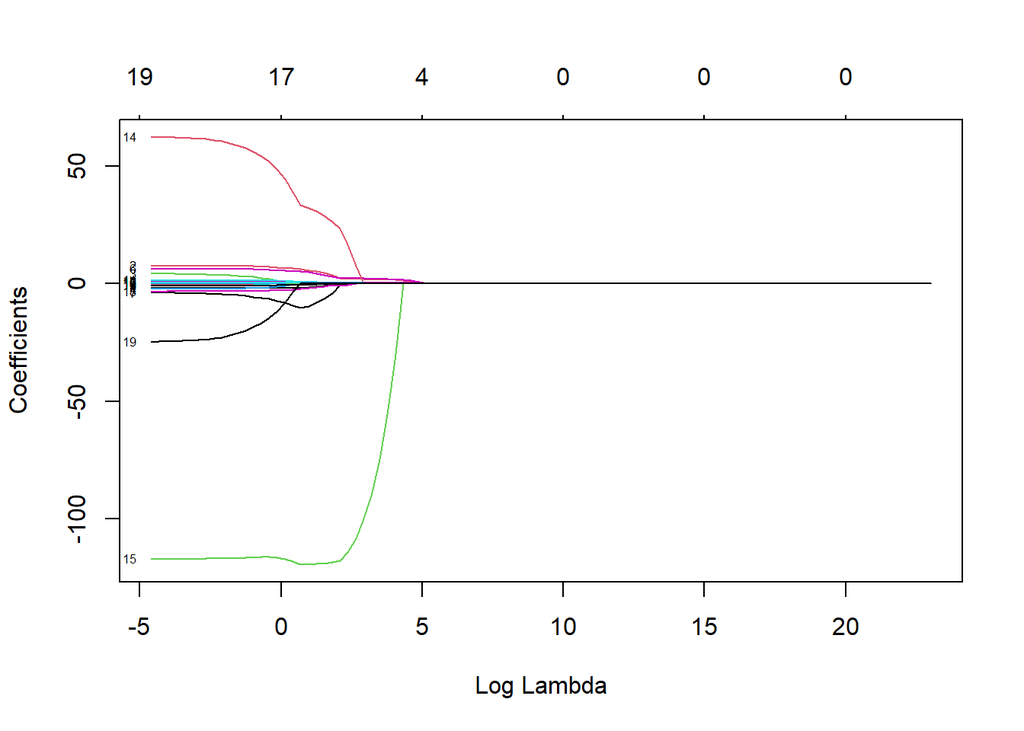

```r
grid = 10^seq(10, -2, length = 100)
lasso.mod <- glmnet(x, y, alpha=1, lambda=grid)
plot(lasso.mod, xvar="lambda", label = TRUE)
```

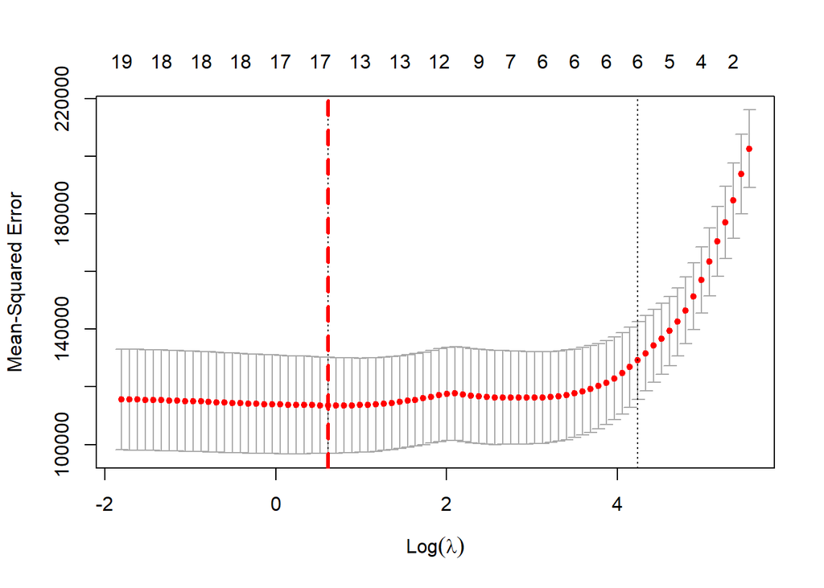

```r
set.seed(1)
cv.out.lasso = cv.glmnet(x, y, alpha = 1)
plot(cv.out.lasso)
abline(v = log(cv.out.lasso$lambda.min), col="red", lwd=3, lty=2)
```

```r
bestlam = cv.out.lasso$lambda.min
bestlam
```

```
## [1] 1.843343
```

The lasso has a substantial advantage over ridge regression in that the resulting coefficient estimates are sparse. Here we see that some of the 19 coefficient estimates are exactly zero.

```r
out=glmnet(x,y,alpha=1,lambda=grid)
lasso.coef=predict(out,type="coefficients",s=bestlam)[1:20,]
lasso.coef
```

```
##   (Intercept)         AtBat          Hits         HmRun          Runs
##  1.418021e+02 -1.777554e+00  6.176690e+00  2.708846e-01 -7.050538e-02
##           RBI         Walks         Years        CAtBat         CHits
##  0.000000e+00  5.139758e+00 -1.009351e+01 -9.197719e-03  0.000000e+00
##        CHmRun         CRuns          CRBI        CWalks       LeagueN
##  5.360893e-01  7.774982e-01  4.115870e-01 -6.255290e-01  3.523070e+01
##     DivisionW       PutOuts       Assists        Errors    NewLeagueN
## -1.189054e+02  2.784890e-01  2.242065e-01 -2.444054e+00 -1.154487e+00
```